# Four Quadrant Plot Analysis

```r
knitr::opts_chunk$set(echo = TRUE, warning = FALSE, message = FALSE)
```

# Introduction

This R Markdown document demonstrates how to create a four quadrant plot for analyzing differential expression data from two different conditions or datasets. The plot is particularly useful for integrative analysis of multi-omics data or comparing different experimental conditions.

# Package Installation and Loading

```r
# Install required packages if not already installed
if (!requireNamespace("ggplot2", quietly = TRUE))
  install.packages("ggplot2")
if (!requireNamespace("ggpubr", quietly = TRUE))
  install.packages("ggpubr")
if (!requireNamespace("ggrepel", quietly = TRUE))
  install.packages("ggrepel")

# Load required packages
library(ggplot2)
library(ggpubr)
library(ggrepel)
```

# Data Loading and Preparation

The input data should be a CSV file with the following columns: - geneid: Gene identifiers - log2FoldChange: First log2 fold change values (Y-axis) - padj_a: Adjusted p-values for first comparison - diff.log2.fc: Second log2 fold change values (X-axis) - padj_b: Adjusted p-values for second comparison - label: Genes to be labeled on the plot (optional)

```r
# Read the example data
data <- read.csv("four_quadrant_example.csv", header = TRUE)
head(data)
```

```
##               geneid log2FoldChange    padj_a diff.log2.fc       padj_b  label
## 1 ENSMUSG00000032503       9.255800  4.68e-17     4.689613 3.630781e-03 Arpp21
## 2 ENSMUSG00000030592       8.786357  0.00e+00    -1.392335 4.677351e-03   Ryr1
## 3 ENSMUSG00000051747       8.224613  1.06e-71     1.235751 1.580000e-11    Ttn
## 4 ENSMUSG00000091898       7.916411  0.00e+00    -1.181684 3.715352e-03  Tnnc1
## 5 ENSMUSG00000090210       7.087492 1.57e-156    -1.785926 1.778279e-03 Itga10
## 6 ENSMUSG00000028328       5.955109  7.03e-93     3.738576 5.010000e-22  Tmod1
```

# Data Processing

We’ll categorize the genes into different groups based on their fold changes and significance:

```r
# Set thresholds
fc1 <- 0  # Y-axis fold change threshold
fc2 <- 0  # X-axis fold change threshold
p_threshold <- 0.05  # Significance threshold

# Create group column
data$group <- "none"

# Categorize genes based on fold changes and p-values
data$group[data$log2FoldChange > fc1 &
           data$diff.log2.fc > fc2 &
           data$padj_a <= p_threshold &
           data$padj_b <= p_threshold] <- "Hyper-up"

data$group[data$log2FoldChange < -fc1 &
           data$diff.log2.fc > fc2 &
           data$padj_a <= p_threshold &
           data$padj_b <= p_threshold] <- "Hyper-down"

data$group[data$log2FoldChange < -fc1 &
           data$diff.log2.fc < -fc2 &
           data$padj_a <= p_threshold &
           data$padj_b <= p_threshold] <- "Hypo-down"

data$group[data$log2FoldChange > fc1 &
           data$diff.log2.fc < -fc2 &
           data$padj_a <= p_threshold &
           data$padj_b <= p_threshold] <- "Hypo-up"

# Convert group to factor with specific order
data$group <- factor(data$group,
                    levels = c("none", "Hyper-up", "Hypo-up", "Hypo-down", "Hyper-down"))

# Count genes in each category
gene_counts <- table(data$group)
print(gene_counts)
```

```
##
##       none   Hyper-up    Hypo-up  Hypo-down Hyper-down
##       1114       1037        761        524        680
```

# Creating the Four Quadrant Plot

Now we’ll create the plot using ggplot2. We’ll use different colors for each quadrant and add labels for significant genes.

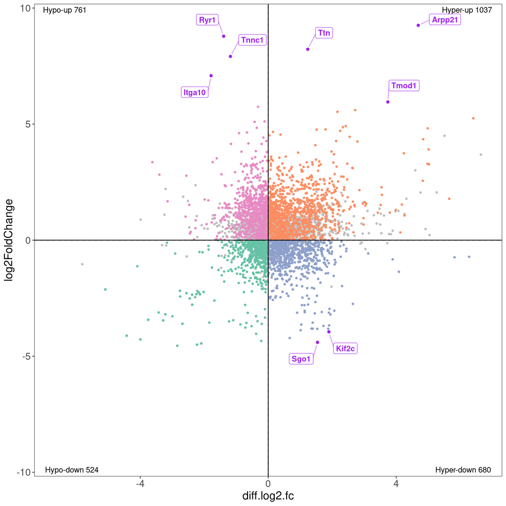

```r
# Create labels for gene counts
s1 <- paste("Hyper-up", gene_counts["Hyper-up"])
s2 <- paste("Hypo-up", gene_counts["Hypo-up"])
s3 <- paste("Hypo-down", gene_counts["Hypo-down"])
s4 <- paste("Hyper-down", gene_counts["Hyper-down"])

# Create the plot
p <- ggplot(data = data,
            aes(x = diff.log2.fc, y = log2FoldChange, color = group, label = label)) +
  # Add points for each category with specific colors
  geom_point(data = data[data$group == "none",], color = "gray", size = 1, alpha = 1) +
  geom_point(data = data[data$group == "Hyper-up",], color = "#fc8d62", size = 1, alpha = 1) +
  geom_point(data = data[data$group == "Hypo-up",], color = "#e78ac3", size = 1, alpha = 1) +
  geom_point(data = data[data$group == "Hypo-down",], color = "#66c2a5", size = 1, alpha = 1) +
  geom_point(data = data[data$group == "Hyper-down",], color = "#8da0cb", size = 1, alpha = 1) +

  # Add reference lines
  theme_bw() +
  geom_hline(yintercept = 0, linetype = 1) +
  geom_hline(yintercept = c(-fc1, fc1), linetype = 2) +
  geom_vline(xintercept = c(-fc2, fc2), linetype = 2) +
  geom_vline(xintercept = 0, linetype = 1) +

  # Set axis limits
  xlim(c(-max(abs(data$diff.log2.fc)), max(abs(data$diff.log2.fc)))) +
  ylim(c(-max(abs(data$log2FoldChange)), max(abs(data$log2FoldChange)))) +

  # Customize theme
  theme(
    panel.grid = element_blank(),
    axis.title = element_text(size = 16),
    axis.text = element_text(size = 14)
  ) +

  # Add count labels
  annotate(geom = 'text', label = s1, x = Inf, y = Inf, hjust = 1.2, vjust = 1.5) +
  annotate(geom = 'text', label = s2, x = -Inf, y = Inf, hjust = -0.2, vjust = 1.5) +
  annotate(geom = 'text', label = s3, x = -Inf, y = -Inf, hjust = -0.2, vjust = -0.7) +
  annotate(geom = 'text', label = s4, x = Inf, y = -Inf, hjust = 1.2, vjust = -0.7) +

  # Add gene labels
  geom_label_repel(
    fontface = "bold",
    color = "purple",
    box.padding = unit(1, "lines"),
    point.padding = unit(0.5, "lines"),
    segment.colour = "purple",
    segment.size = 0.5,
    segment.alpha = 0.5,
    max.overlaps = Inf
  ) +

  # Highlight labeled points
  geom_point(data = data[data$label != "",], color = "purple") +

  # Add legend
  labs(color = "class")

# Display the plot
print(p)
```

# Save the Plot

You can save the plot in various formats:

```r
# Save as PDF
ggsave("four_quadrant_plot.pdf", p, width = 10, height = 10)

# Save as PNG
ggsave("four_quadrant_plot.png", p, width = 10, height = 10, dpi = 300)

# Save as TIFF
ggsave("four_quadrant_plot.tiff", p, width = 10, height = 10, dpi = 300)

# Save as JPEG
ggsave("four_quadrant_plot.jpeg", p, width = 10, height = 10, dpi = 300)
```

# Interpretation

The four quadrant plot divides genes into different categories:

1. Hyper-up (upper right): Genes upregulated in both conditions
2. Hyper-down (lower right): Genes downregulated in condition 1 but upregulated in condition 2
3. Hypo-down (lower left): Genes downregulated in both conditions
4. Hypo-up (upper left): Genes upregulated in condition 1 but downregulated in condition 2

Gray points represent genes that don’t meet the significance threshold (p > 0.05) or fold change criteria. Labeled genes are highlighted in purple with connecting lines to their labels.

This R Markdown document provides a comprehensive guide to creating and interpreting four quadrant plots, with detailed explanations and customization options. Users can easily modify the thresholds, colors, and other parameters to suit their needs.

The code includes proper error handling for package installation, detailed comments, and clear explanations of each step. The output includes both the visualization and the underlying data processing steps, making it easy for users to understand and modify the analysis for their own data.